# Risk Factor Analysis

## Outcome Variable

**Outcome Variable:** ever_swasted

## Predictor Variables

**Intervention Variable:** month

**Adjustment Set:**

unadjusted

## Stratifying Variables

The analysis was stratified on these variable(s):

- agecat
- studyid
- country

## Data Summary

| agecat | studyid | country | month | ever_swasted | n_cell | n |
| --- | --- | --- | --- | --- | --- | --- |
| 0-24 months (no birth wast) | ki0047075b-MAL-ED | BANGLADESH | 1 | 0 | 22 | 263 |
| 0-24 months (no birth wast) | ki0047075b-MAL-ED | BANGLADESH | 1 | 1 | 0 | 263 |
| 0-24 months (no birth wast) | ki0047075b-MAL-ED | BANGLADESH | 2 | 0 | 23 | 263 |
| 0-24 months (no birth wast) | ki0047075b-MAL-ED | BANGLADESH | 2 | 1 | 1 | 263 |
| 0-24 months (no birth wast) | ki0047075b-MAL-ED | BANGLADESH | 3 | 0 | 22 | 263 |
| 0-24 months (no birth wast) | ki0047075b-MAL-ED | BANGLADESH | 3 | 1 | 4 | 263 |
| 0-24 months (no birth wast) | ki0047075b-MAL-ED | BANGLADESH | 4 | 0 | 23 | 263 |
| 0-24 months (no birth wast) | ki0047075b-MAL-ED | BANGLADESH | 4 | 1 | 1 | 263 |
| 0-24 months (no birth wast) | ki0047075b-MAL-ED | BANGLADESH | 5 | 0 | 17 | 263 |
| 0-24 months (no birth wast) | ki0047075b-MAL-ED | BANGLADESH | 5 | 1 | 1 | 263 |
| 0-24 months (no birth wast) | ki0047075b-MAL-ED | BANGLADESH | 6 | 0 | 13 | 263 |
| 0-24 months (no birth wast) | ki0047075b-MAL-ED | BANGLADESH | 6 | 1 | 0 | 263 |
| 0-24 months (no birth wast) | ki0047075b-MAL-ED | BANGLADESH | 7 | 0 | 17 | 263 |
| 0-24 months (no birth wast) | ki0047075b-MAL-ED | BANGLADESH | 7 | 1 | 1 | 263 |
| 0-24 months (no birth wast) | ki0047075b-MAL-ED | BANGLADESH | 8 | 0 | 29 | 263 |
| 0-24 months (no birth wast) | ki0047075b-MAL-ED | BANGLADESH | 8 | 1 | 0 | 263 |
| 0-24 months (no birth wast) | ki0047075b-MAL-ED | BANGLADESH | 9 | 0 | 21 | 263 |
| 0-24 months (no birth wast) | ki0047075b-MAL-ED | BANGLADESH | 9 | 1 | 1 | 263 |
| 0-24 months (no birth wast) | ki0047075b-MAL-ED | BANGLADESH | 10 | 0 | 21 | 263 |
| 0-24 months (no birth wast) | ki0047075b-MAL-ED | BANGLADESH | 10 | 1 | 2 | 263 |
| 0-24 months (no birth wast) | ki0047075b-MAL-ED | BANGLADESH | 11 | 0 | 16 | 263 |
| 0-24 months (no birth wast) | ki0047075b-MAL-ED | BANGLADESH | 11 | 1 | 0 | 263 |
| 0-24 months (no birth wast) | ki0047075b-MAL-ED | BANGLADESH | 12 | 0 | 27 | 263 |
| 0-24 months (no birth wast) | ki0047075b-MAL-ED | BANGLADESH | 12 | 1 | 1 | 263 |
| 0-24 months (no birth wast) | ki0047075b-MAL-ED | BRAZIL | 1 | 0 | 15 | 233 |
| 0-24 months (no birth wast) | ki0047075b-MAL-ED | BRAZIL | 1 | 1 | 0 | 233 |
| 0-24 months (no birth wast) | ki0047075b-MAL-ED | BRAZIL | 2 | 0 | 25 | 233 |
| 0-24 months (no birth wast) | ki0047075b-MAL-ED | BRAZIL | 2 | 1 | 0 | 233 |
| 0-24 months (no birth wast) | ki0047075b-MAL-ED | BRAZIL | 3 | 0 | 18 | 233 |
| 0-24 months (no birth wast) | ki0047075b-MAL-ED | BRAZIL | 3 | 1 | 0 | 233 |

[output cut: 1818 more lines]

The following strata were considered:

- agecat: 0-24 months (no birth wast), studyid: ki0047075b-MAL-ED, country: BANGLADESH
- agecat: 0-24 months (no birth wast), studyid: ki0047075b-MAL-ED, country: BRAZIL
- agecat: 0-24 months (no birth wast), studyid: ki0047075b-MAL-ED, country: INDIA
- agecat: 0-24 months (no birth wast), studyid: ki0047075b-MAL-ED, country: NEPAL
- agecat: 0-24 months (no birth wast), studyid: ki0047075b-MAL-ED, country: PERU
- agecat: 0-24 months (no birth wast), studyid: ki0047075b-MAL-ED, country: SOUTH AFRICA
- agecat: 0-24 months (no birth wast), studyid: ki0047075b-MAL-ED, country: TANZANIA, UNITED REPUBLIC OF
- agecat: 0-24 months (no birth wast), studyid: ki1000108-CMC-V-BCS-2002, country: INDIA
- agecat: 0-24 months (no birth wast), studyid: ki1000108-IRC, country: INDIA
- agecat: 0-24 months (no birth wast), studyid: ki1000109-EE, country: PAKISTAN
- agecat: 0-24 months (no birth wast), studyid: ki1000109-ResPak, country: PAKISTAN
- agecat: 0-24 months (no birth wast), studyid: ki1000304b-SAS-CompFeed, country: INDIA
- agecat: 0-24 months (no birth wast), studyid: ki1000304b-SAS-FoodSuppl, country: INDIA
- agecat: 0-24 months (no birth wast), studyid: ki1017093-NIH-Birth, country: BANGLADESH
- agecat: 0-24 months (no birth wast), studyid: ki1066203-TanzaniaChild2, country: TANZANIA, UNITED REPUBLIC OF
- agecat: 0-24 months (no birth wast), studyid: ki1101329-Keneba, country: GAMBIA
- agecat: 0-24 months (no birth wast), studyid: ki1112895-Guatemala BSC, country: GUATEMALA
- agecat: 0-24 months (no birth wast), studyid: ki1112895-iLiNS-Zinc, country: BURKINA FASO
- agecat: 0-24 months (no birth wast), studyid: ki1113344-GMS-Nepal, country: NEPAL
- agecat: 0-24 months (no birth wast), studyid: ki1114097-CMIN, country: BANGLADESH
- agecat: 0-24 months (no birth wast), studyid: ki1114097-CONTENT, country: PERU
- agecat: 0-24 months (no birth wast), studyid: ki1119695-PROBIT, country: BELARUS
- agecat: 0-24 months (no birth wast), studyid: ki1126311-ZVITAMBO, country: ZIMBABWE
- agecat: 0-24 months (no birth wast), studyid: ki1148112-LCNI-5, country: MALAWI
- agecat: 0-24 months (no birth wast), studyid: kiGH5241-JiVitA-3, country: BANGLADESH
- agecat: 0-24 months (no birth wast), studyid: kiGH5241-JiVitA-4, country: BANGLADESH
- agecat: 0-6 months (no birth wast), studyid: ki0047075b-MAL-ED, country: BANGLADESH
- agecat: 0-6 months (no birth wast), studyid: ki0047075b-MAL-ED, country: BRAZIL
- agecat: 0-6 months (no birth wast), studyid: ki0047075b-MAL-ED, country: INDIA
- agecat: 0-6 months (no birth wast), studyid: ki0047075b-MAL-ED, country: NEPAL
- agecat: 0-6 months (no birth wast), studyid: ki0047075b-MAL-ED, country: PERU
- agecat: 0-6 months (no birth wast), studyid: ki0047075b-MAL-ED, country: SOUTH AFRICA
- agecat: 0-6 months (no birth wast), studyid: ki0047075b-MAL-ED, country: TANZANIA, UNITED REPUBLIC OF
- agecat: 0-6 months (no birth wast), studyid: ki1000108-CMC-V-BCS-2002, country: INDIA
- agecat: 0-6 months (no birth wast), studyid: ki1000108-IRC, country: INDIA
- agecat: 0-6 months (no birth wast), studyid: ki1000109-EE, country: PAKISTAN
- agecat: 0-6 months (no birth wast), studyid: ki1000109-ResPak, country: PAKISTAN
- agecat: 0-6 months (no birth wast), studyid: ki1000304b-SAS-CompFeed, country: INDIA
- agecat: 0-6 months (no birth wast), studyid: ki1000304b-SAS-FoodSuppl, country: INDIA
- agecat: 0-6 months (no birth wast), studyid: ki1017093-NIH-Birth, country: BANGLADESH
- agecat: 0-6 months (no birth wast), studyid: ki1066203-TanzaniaChild2, country: TANZANIA, UNITED REPUBLIC OF
- agecat: 0-6 months (no birth wast), studyid: ki1101329-Keneba, country: GAMBIA
- agecat: 0-6 months (no birth wast), studyid: ki1112895-Guatemala BSC, country: GUATEMALA
- agecat: 0-6 months (no birth wast), studyid: ki1113344-GMS-Nepal, country: NEPAL
- agecat: 0-6 months (no birth wast), studyid: ki1114097-CMIN, country: BANGLADESH
- agecat: 0-6 months (no birth wast), studyid: ki1114097-CONTENT, country: PERU
- agecat: 0-6 months (no birth wast), studyid: ki1119695-PROBIT, country: BELARUS
- agecat: 0-6 months (no birth wast), studyid: ki1126311-ZVITAMBO, country: ZIMBABWE
- agecat: 0-6 months (no birth wast), studyid: ki1148112-LCNI-5, country: MALAWI
- agecat: 0-6 months (no birth wast), studyid: kiGH5241-JiVitA-3, country: BANGLADESH
- agecat: 0-6 months (no birth wast), studyid: kiGH5241-JiVitA-4, country: BANGLADESH
- agecat: 6-24 months, studyid: ki0047075b-MAL-ED, country: BANGLADESH
- agecat: 6-24 months, studyid: ki0047075b-MAL-ED, country: BRAZIL
- agecat: 6-24 months, studyid: ki0047075b-MAL-ED, country: INDIA
- agecat: 6-24 months, studyid: ki0047075b-MAL-ED, country: NEPAL
- agecat: 6-24 months, studyid: ki0047075b-MAL-ED, country: PERU
- agecat: 6-24 months, studyid: ki0047075b-MAL-ED, country: SOUTH AFRICA
- agecat: 6-24 months, studyid: ki0047075b-MAL-ED, country: TANZANIA, UNITED REPUBLIC OF
- agecat: 6-24 months, studyid: ki1000108-CMC-V-BCS-2002, country: INDIA
- agecat: 6-24 months, studyid: ki1000108-IRC, country: INDIA
- agecat: 6-24 months, studyid: ki1000109-EE, country: PAKISTAN
- agecat: 6-24 months, studyid: ki1000109-ResPak, country: PAKISTAN
- agecat: 6-24 months, studyid: ki1000304b-SAS-CompFeed, country: INDIA
- agecat: 6-24 months, studyid: ki1000304b-SAS-FoodSuppl, country: INDIA
- agecat: 6-24 months, studyid: ki1017093-NIH-Birth, country: BANGLADESH
- agecat: 6-24 months, studyid: ki1066203-TanzaniaChild2, country: TANZANIA, UNITED REPUBLIC OF
- agecat: 6-24 months, studyid: ki1101329-Keneba, country: GAMBIA
- agecat: 6-24 months, studyid: ki1112895-Guatemala BSC, country: GUATEMALA
- agecat: 6-24 months, studyid: ki1112895-iLiNS-Zinc, country: BURKINA FASO
- agecat: 6-24 months, studyid: ki1113344-GMS-Nepal, country: NEPAL
- agecat: 6-24 months, studyid: ki1114097-CMIN, country: BANGLADESH
- agecat: 6-24 months, studyid: ki1114097-CONTENT, country: PERU
- agecat: 6-24 months, studyid: ki1119695-PROBIT, country: BELARUS
- agecat: 6-24 months, studyid: ki1126311-ZVITAMBO, country: ZIMBABWE
- agecat: 6-24 months, studyid: ki1148112-LCNI-5, country: MALAWI
- agecat: 6-24 months, studyid: kiGH5241-JiVitA-3, country: BANGLADESH
- agecat: 6-24 months, studyid: kiGH5241-JiVitA-4, country: BANGLADESH

### Dropped Strata

Some strata were dropped due to rare outcomes:

- agecat: 0-24 months (no birth wast), studyid: ki0047075b-MAL-ED, country: BANGLADESH
- agecat: 0-24 months (no birth wast), studyid: ki0047075b-MAL-ED, country: BRAZIL
- agecat: 0-24 months (no birth wast), studyid: ki0047075b-MAL-ED, country: INDIA
- agecat: 0-24 months (no birth wast), studyid: ki0047075b-MAL-ED, country: NEPAL
- agecat: 0-24 months (no birth wast), studyid: ki0047075b-MAL-ED, country: PERU
- agecat: 0-24 months (no birth wast), studyid: ki0047075b-MAL-ED, country: SOUTH AFRICA
- agecat: 0-24 months (no birth wast), studyid: ki0047075b-MAL-ED, country: TANZANIA, UNITED REPUBLIC OF
- agecat: 0-24 months (no birth wast), studyid: ki1000108-CMC-V-BCS-2002, country: INDIA
- agecat: 0-24 months (no birth wast), studyid: ki1000108-IRC, country: INDIA
- agecat: 0-24 months (no birth wast), studyid: ki1000109-EE, country: PAKISTAN
- agecat: 0-24 months (no birth wast), studyid: ki1000109-ResPak, country: PAKISTAN
- agecat: 0-24 months (no birth wast), studyid: ki1000304b-SAS-FoodSuppl, country: INDIA
- agecat: 0-24 months (no birth wast), studyid: ki1017093-NIH-Birth, country: BANGLADESH
- agecat: 0-24 months (no birth wast), studyid: ki1112895-Guatemala BSC, country: GUATEMALA
- agecat: 0-24 months (no birth wast), studyid: ki1112895-iLiNS-Zinc, country: BURKINA FASO
- agecat: 0-24 months (no birth wast), studyid: ki1113344-GMS-Nepal, country: NEPAL
- agecat: 0-24 months (no birth wast), studyid: ki1114097-CMIN, country: BANGLADESH
- agecat: 0-24 months (no birth wast), studyid: ki1114097-CONTENT, country: PERU
- agecat: 0-24 months (no birth wast), studyid: ki1148112-LCNI-5, country: MALAWI
- agecat: 0-24 months (no birth wast), studyid: kiGH5241-JiVitA-4, country: BANGLADESH
- agecat: 0-6 months (no birth wast), studyid: ki0047075b-MAL-ED, country: BANGLADESH
- agecat: 0-6 months (no birth wast), studyid: ki0047075b-MAL-ED, country: BRAZIL
- agecat: 0-6 months (no birth wast), studyid: ki0047075b-MAL-ED, country: INDIA
- agecat: 0-6 months (no birth wast), studyid: ki0047075b-MAL-ED, country: NEPAL
- agecat: 0-6 months (no birth wast), studyid: ki0047075b-MAL-ED, country: PERU
- agecat: 0-6 months (no birth wast), studyid: ki0047075b-MAL-ED, country: SOUTH AFRICA
- agecat: 0-6 months (no birth wast), studyid: ki0047075b-MAL-ED, country: TANZANIA, UNITED REPUBLIC OF
- agecat: 0-6 months (no birth wast), studyid: ki1000108-CMC-V-BCS-2002, country: INDIA
- agecat: 0-6 months (no birth wast), studyid: ki1000108-IRC, country: INDIA
- agecat: 0-6 months (no birth wast), studyid: ki1000109-EE, country: PAKISTAN
- agecat: 0-6 months (no birth wast), studyid: ki1000109-ResPak, country: PAKISTAN
- agecat: 0-6 months (no birth wast), studyid: ki1000304b-SAS-CompFeed, country: INDIA
- agecat: 0-6 months (no birth wast), studyid: ki1000304b-SAS-FoodSuppl, country: INDIA
- agecat: 0-6 months (no birth wast), studyid: ki1017093-NIH-Birth, country: BANGLADESH
- agecat: 0-6 months (no birth wast), studyid: ki1066203-TanzaniaChild2, country: TANZANIA, UNITED REPUBLIC OF
- agecat: 0-6 months (no birth wast), studyid: ki1112895-Guatemala BSC, country: GUATEMALA
- agecat: 0-6 months (no birth wast), studyid: ki1113344-GMS-Nepal, country: NEPAL
- agecat: 0-6 months (no birth wast), studyid: ki1114097-CMIN, country: BANGLADESH
- agecat: 0-6 months (no birth wast), studyid: ki1114097-CONTENT, country: PERU
- agecat: 0-6 months (no birth wast), studyid: ki1126311-ZVITAMBO, country: ZIMBABWE
- agecat: 0-6 months (no birth wast), studyid: ki1148112-LCNI-5, country: MALAWI
- agecat: 0-6 months (no birth wast), studyid: kiGH5241-JiVitA-4, country: BANGLADESH
- agecat: 6-24 months, studyid: ki0047075b-MAL-ED, country: BANGLADESH
- agecat: 6-24 months, studyid: ki0047075b-MAL-ED, country: BRAZIL
- agecat: 6-24 months, studyid: ki0047075b-MAL-ED, country: INDIA
- agecat: 6-24 months, studyid: ki0047075b-MAL-ED, country: NEPAL
- agecat: 6-24 months, studyid: ki0047075b-MAL-ED, country: PERU
- agecat: 6-24 months, studyid: ki0047075b-MAL-ED, country: SOUTH AFRICA
- agecat: 6-24 months, studyid: ki0047075b-MAL-ED, country: TANZANIA, UNITED REPUBLIC OF
- agecat: 6-24 months, studyid: ki1000108-CMC-V-BCS-2002, country: INDIA
- agecat: 6-24 months, studyid: ki1000108-IRC, country: INDIA
- agecat: 6-24 months, studyid: ki1000109-EE, country: PAKISTAN
- agecat: 6-24 months, studyid: ki1000109-ResPak, country: PAKISTAN
- agecat: 6-24 months, studyid: ki1000304b-SAS-CompFeed, country: INDIA
- agecat: 6-24 months, studyid: ki1000304b-SAS-FoodSuppl, country: INDIA
- agecat: 6-24 months, studyid: ki1017093-NIH-Birth, country: BANGLADESH
- agecat: 6-24 months, studyid: ki1066203-TanzaniaChild2, country: TANZANIA, UNITED REPUBLIC OF
- agecat: 6-24 months, studyid: ki1112895-Guatemala BSC, country: GUATEMALA
- agecat: 6-24 months, studyid: ki1113344-GMS-Nepal, country: NEPAL
- agecat: 6-24 months, studyid: ki1114097-CMIN, country: BANGLADESH
- agecat: 6-24 months, studyid: ki1114097-CONTENT, country: PERU
- agecat: 6-24 months, studyid: ki1119695-PROBIT, country: BELARUS
- agecat: 6-24 months, studyid: ki1148112-LCNI-5, country: MALAWI
- agecat: 6-24 months, studyid: kiGH5241-JiVitA-4, country: BANGLADESH

## Methods Detail

We’re interested in the causal parameters $E[Y_a]$ for all values of $a \in \mathcal{A}$. These parameters represent the mean outcome if, possibly contrary to fact, we intervened to set all units to have $A=a$. Under the randomization and positivity assumptions, these are identified by the statistical parameters $\psi_a=E_W[E_{Y|A,W}(Y|A=a,W)]$. In addition, we’re interested in the mean of $Y$, $E[Y]$ under no intervention (the observed mean). We will estimate these parameters by using SuperLearner to fit the relevant likelihood factors – $E_{Y|A,W}(Y|A=a,W)$ and $p(A=a|W)$, and then updating our likelihood fit using a joint TMLE.

For unadjusted analyses ($W=\{\}$), initial likelihoods were estimated using Lrnr_glm to estimate the simple $E(Y|A)$ and Lrnr_mean to estimate $p(A)$. For adjusted analyses, a small library containing Lrnr_glmnet, Lrnr_xgboost, and Lrnr_mean was used.

Having estimated these parameters, we will then use the delta method to estimate relative risks and attributable risks relative to a prespecified baseline level of $A$.

# Results Detail

## Results Plots

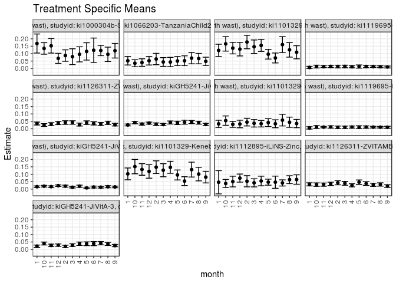

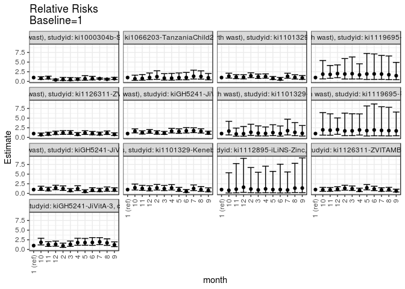

[figure not shown]

[figure not shown]

## Results Table

### Parameter: TSM

| agecat | studyid | country | intervention_level | baseline_level | estimate | ci_lower | ci_upper |
| --- | --- | --- | --- | --- | --- | --- | --- |
| 0-24 months (no birth wast) | ki1000304b-SAS-CompFeed | INDIA | 1 | NA | 0.1682243 | 0.1039350 | 0.2325136 |
| 0-24 months (no birth wast) | ki1000304b-SAS-CompFeed | INDIA | 2 | NA | 0.0869565 | 0.0483028 | 0.1256102 |
| 0-24 months (no birth wast) | ki1000304b-SAS-CompFeed | INDIA | 3 | NA | 0.0795455 | 0.0261268 | 0.1329641 |
| 0-24 months (no birth wast) | ki1000304b-SAS-CompFeed | INDIA | 4 | NA | 0.0952381 | 0.0443913 | 0.1460849 |
| 0-24 months (no birth wast) | ki1000304b-SAS-CompFeed | INDIA | 5 | NA | 0.1149425 | 0.0564882 | 0.1733969 |
| 0-24 months (no birth wast) | ki1000304b-SAS-CompFeed | INDIA | 6 | NA | 0.1228070 | 0.0403659 | 0.2052481 |
| 0-24 months (no birth wast) | ki1000304b-SAS-CompFeed | INDIA | 7 | NA | 0.1209677 | 0.0863229 | 0.1556126 |
| 0-24 months (no birth wast) | ki1000304b-SAS-CompFeed | INDIA | 8 | NA | 0.0952381 | 0.0467417 | 0.1437345 |
| 0-24 months (no birth wast) | ki1000304b-SAS-CompFeed | INDIA | 9 | NA | 0.1195652 | 0.0703630 | 0.1687675 |
| 0-24 months (no birth wast) | ki1000304b-SAS-CompFeed | INDIA | 10 | NA | 0.1349693 | 0.0960680 | 0.1738707 |
| 0-24 months (no birth wast) | ki1000304b-SAS-CompFeed | INDIA | 11 | NA | 0.1527778 | 0.1038420 | 0.2017135 |
| 0-24 months (no birth wast) | ki1000304b-SAS-CompFeed | INDIA | 12 | NA | 0.0680272 | 0.0339271 | 0.1021273 |
| 0-24 months (no birth wast) | ki1066203-TanzaniaChild2 | TANZANIA, UNITED REPUBLIC OF | 1 | NA | 0.0519481 | 0.0233238 | 0.0805723 |
| 0-24 months (no birth wast) | ki1066203-TanzaniaChild2 | TANZANIA, UNITED REPUBLIC OF | 2 | NA | 0.0636943 | 0.0254868 | 0.1019017 |
| 0-24 months (no birth wast) | ki1066203-TanzaniaChild2 | TANZANIA, UNITED REPUBLIC OF | 3 | NA | 0.0437158 | 0.0140862 | 0.0733455 |
| 0-24 months (no birth wast) | ki1066203-TanzaniaChild2 | TANZANIA, UNITED REPUBLIC OF | 4 | NA | 0.0434783 | 0.0119711 | 0.0749855 |
| 0-24 months (no birth wast) | ki1066203-TanzaniaChild2 | TANZANIA, UNITED REPUBLIC OF | 5 | NA | 0.0502513 | 0.0198920 | 0.0806105 |
| 0-24 months (no birth wast) | ki1066203-TanzaniaChild2 | TANZANIA, UNITED REPUBLIC OF | 6 | NA | 0.0520231 | 0.0189242 | 0.0851220 |
| 0-24 months (no birth wast) | ki1066203-TanzaniaChild2 | TANZANIA, UNITED REPUBLIC OF | 7 | NA | 0.0697674 | 0.0316874 | 0.1078475 |
| 0-24 months (no birth wast) | ki1066203-TanzaniaChild2 | TANZANIA, UNITED REPUBLIC OF | 8 | NA | 0.0666667 | 0.0316484 | 0.1016849 |
| 0-24 months (no birth wast) | ki1066203-TanzaniaChild2 | TANZANIA, UNITED REPUBLIC OF | 9 | NA | 0.0482456 | 0.0204252 | 0.0760660 |
| 0-24 months (no birth wast) | ki1066203-TanzaniaChild2 | TANZANIA, UNITED REPUBLIC OF | 10 | NA | 0.0350877 | 0.0111990 | 0.0589765 |
| 0-24 months (no birth wast) | ki1066203-TanzaniaChild2 | TANZANIA, UNITED REPUBLIC OF | 11 | NA | 0.0398230 | 0.0143237 | 0.0653223 |
| 0-24 months (no birth wast) | ki1066203-TanzaniaChild2 | TANZANIA, UNITED REPUBLIC OF | 12 | NA | 0.0519481 | 0.0233238 | 0.0805723 |
| 0-24 months (no birth wast) | ki1101329-Keneba | GAMBIA | 1 | NA | 0.1218487 | 0.0802835 | 0.1634140 |
| 0-24 months (no birth wast) | ki1101329-Keneba | GAMBIA | 2 | NA | 0.1781818 | 0.1329466 | 0.2234171 |
| 0-24 months (no birth wast) | ki1101329-Keneba | GAMBIA | 3 | NA | 0.1465517 | 0.1010357 | 0.1920677 |
| 0-24 months (no birth wast) | ki1101329-Keneba | GAMBIA | 4 | NA | 0.1553398 | 0.1149449 | 0.1957347 |
| 0-24 months (no birth wast) | ki1101329-Keneba | GAMBIA | 5 | NA | 0.0961538 | 0.0634366 | 0.1288711 |
| 0-24 months (no birth wast) | ki1101329-Keneba | GAMBIA | 6 | NA | 0.0707965 | 0.0373515 | 0.1042414 |

[output cut: 126 more lines]

### Parameter: E(Y)

| agecat | studyid | country | intervention_level | baseline_level | estimate | ci_lower | ci_upper |
| --- | --- | --- | --- | --- | --- | --- | --- |
| 0-24 months (no birth wast) | ki1000304b-SAS-CompFeed | INDIA | NA | NA | 0.1145140 | 0.0913579 | 0.1376700 |
| 0-24 months (no birth wast) | ki1066203-TanzaniaChild2 | TANZANIA, UNITED REPUBLIC OF | NA | NA | 0.0507550 | 0.0419422 | 0.0595679 |
| 0-24 months (no birth wast) | ki1101329-Keneba | GAMBIA | NA | NA | 0.1335425 | 0.1210912 | 0.1459939 |
| 0-24 months (no birth wast) | ki1119695-PROBIT | BELARUS | NA | NA | 0.0120875 | 0.0084025 | 0.0157724 |
| 0-24 months (no birth wast) | ki1126311-ZVITAMBO | ZIMBABWE | NA | NA | 0.0350517 | 0.0319649 | 0.0381385 |
| 0-24 months (no birth wast) | kiGH5241-JiVitA-3 | BANGLADESH | NA | NA | 0.0357345 | 0.0331597 | 0.0383093 |
| 0-6 months (no birth wast) | ki1101329-Keneba | GAMBIA | NA | NA | 0.0391914 | 0.0314649 | 0.0469180 |
| 0-6 months (no birth wast) | ki1119695-PROBIT | BELARUS | NA | NA | 0.0107462 | 0.0070475 | 0.0144449 |
| 0-6 months (no birth wast) | kiGH5241-JiVitA-3 | BANGLADESH | NA | NA | 0.0165815 | 0.0147663 | 0.0183968 |
| 6-24 months | ki1101329-Keneba | GAMBIA | NA | NA | 0.1172389 | 0.1051866 | 0.1292911 |
| 6-24 months | ki1112895-iLiNS-Zinc | BURKINA FASO | NA | NA | 0.0505205 | 0.0383088 | 0.0627322 |
| 6-24 months | ki1126311-ZVITAMBO | ZIMBABWE | NA | NA | 0.0329172 | 0.0295545 | 0.0362800 |
| 6-24 months | kiGH5241-JiVitA-3 | BANGLADESH | NA | NA | 0.0319690 | 0.0290813 | 0.0348568 |

### Parameter: RR

| agecat | studyid | country | intervention_level | baseline_level | estimate | ci_lower | ci_upper |
| --- | --- | --- | --- | --- | --- | --- | --- |
| 0-24 months (no birth wast) | ki1000304b-SAS-CompFeed | INDIA | 1 | 1 | 1.0000000 | 1.0000000 | 1.0000000 |
| 0-24 months (no birth wast) | ki1000304b-SAS-CompFeed | INDIA | 2 | 1 | 0.5169082 | 0.2569695 | 1.0397892 |
| 0-24 months (no birth wast) | ki1000304b-SAS-CompFeed | INDIA | 3 | 1 | 0.4728535 | 0.2210127 | 1.0116632 |
| 0-24 months (no birth wast) | ki1000304b-SAS-CompFeed | INDIA | 4 | 1 | 0.5661376 | 0.3448096 | 0.9295325 |
| 0-24 months (no birth wast) | ki1000304b-SAS-CompFeed | INDIA | 5 | 1 | 0.6832695 | 0.3107527 | 1.5023429 |
| 0-24 months (no birth wast) | ki1000304b-SAS-CompFeed | INDIA | 6 | 1 | 0.7300195 | 0.4017844 | 1.3264042 |
| 0-24 months (no birth wast) | ki1000304b-SAS-CompFeed | INDIA | 7 | 1 | 0.7190860 | 0.5708124 | 0.9058750 |
| 0-24 months (no birth wast) | ki1000304b-SAS-CompFeed | INDIA | 8 | 1 | 0.5661376 | 0.4110703 | 0.7797005 |
| 0-24 months (no birth wast) | ki1000304b-SAS-CompFeed | INDIA | 9 | 1 | 0.7107488 | 0.4760165 | 1.0612317 |
| 0-24 months (no birth wast) | ki1000304b-SAS-CompFeed | INDIA | 10 | 1 | 0.8023177 | 0.5273449 | 1.2206692 |
| 0-24 months (no birth wast) | ki1000304b-SAS-CompFeed | INDIA | 11 | 1 | 0.9081790 | 0.6046879 | 1.3639915 |
| 0-24 months (no birth wast) | ki1000304b-SAS-CompFeed | INDIA | 12 | 1 | 0.4043840 | 0.2651326 | 0.6167722 |
| 0-24 months (no birth wast) | ki1066203-TanzaniaChild2 | TANZANIA, UNITED REPUBLIC OF | 1 | 1 | 1.0000000 | 1.0000000 | 1.0000000 |
| 0-24 months (no birth wast) | ki1066203-TanzaniaChild2 | TANZANIA, UNITED REPUBLIC OF | 2 | 1 | 1.2261146 | 0.5429854 | 2.7686882 |
| 0-24 months (no birth wast) | ki1066203-TanzaniaChild2 | TANZANIA, UNITED REPUBLIC OF | 3 | 1 | 0.8415301 | 0.3513284 | 2.0157004 |
| 0-24 months (no birth wast) | ki1066203-TanzaniaChild2 | TANZANIA, UNITED REPUBLIC OF | 4 | 1 | 0.8369565 | 0.3367733 | 2.0800232 |
| 0-24 months (no birth wast) | ki1066203-TanzaniaChild2 | TANZANIA, UNITED REPUBLIC OF | 5 | 1 | 0.9673367 | 0.4270317 | 2.1912667 |
| 0-24 months (no birth wast) | ki1066203-TanzaniaChild2 | TANZANIA, UNITED REPUBLIC OF | 6 | 1 | 1.0014451 | 0.4316118 | 2.3235976 |
| 0-24 months (no birth wast) | ki1066203-TanzaniaChild2 | TANZANIA, UNITED REPUBLIC OF | 7 | 1 | 1.3430233 | 0.6183742 | 2.9168608 |
| 0-24 months (no birth wast) | ki1066203-TanzaniaChild2 | TANZANIA, UNITED REPUBLIC OF | 8 | 1 | 1.2833333 | 0.5994102 | 2.7476084 |
| 0-24 months (no birth wast) | ki1066203-TanzaniaChild2 | TANZANIA, UNITED REPUBLIC OF | 9 | 1 | 0.9287281 | 0.4183156 | 2.0619263 |
| 0-24 months (no birth wast) | ki1066203-TanzaniaChild2 | TANZANIA, UNITED REPUBLIC OF | 10 | 1 | 0.6754386 | 0.2813200 | 1.6217025 |
| 0-24 months (no birth wast) | ki1066203-TanzaniaChild2 | TANZANIA, UNITED REPUBLIC OF | 11 | 1 | 0.7665929 | 0.3293741 | 1.7841861 |
| 0-24 months (no birth wast) | ki1066203-TanzaniaChild2 | TANZANIA, UNITED REPUBLIC OF | 12 | 1 | 1.0000000 | 0.4587476 | 2.1798478 |
| 0-24 months (no birth wast) | ki1101329-Keneba | GAMBIA | 1 | 1 | 1.0000000 | 1.0000000 | 1.0000000 |
| 0-24 months (no birth wast) | ki1101329-Keneba | GAMBIA | 2 | 1 | 1.4623197 | 0.9558071 | 2.2372495 |
| 0-24 months (no birth wast) | ki1101329-Keneba | GAMBIA | 3 | 1 | 1.2027348 | 0.7582590 | 1.9077533 |
| 0-24 months (no birth wast) | ki1101329-Keneba | GAMBIA | 4 | 1 | 1.2748577 | 0.8301893 | 1.9577007 |
| 0-24 months (no birth wast) | ki1101329-Keneba | GAMBIA | 5 | 1 | 0.7891247 | 0.4874143 | 1.2775943 |
| 0-24 months (no birth wast) | ki1101329-Keneba | GAMBIA | 6 | 1 | 0.5810192 | 0.3244356 | 1.0405249 |

[output cut: 126 more lines]

### Parameter: PAR

| agecat | studyid | country | intervention_level | baseline_level | estimate | ci_lower | ci_upper |
| --- | --- | --- | --- | --- | --- | --- | --- |
| 0-24 months (no birth wast) | ki1000304b-SAS-CompFeed | INDIA | 1 | NA | -0.0537103 | -0.0998388 | -0.0075819 |
| 0-24 months (no birth wast) | ki1066203-TanzaniaChild2 | TANZANIA, UNITED REPUBLIC OF | 1 | NA | -0.0011930 | -0.0283634 | 0.0259774 |
| 0-24 months (no birth wast) | ki1101329-Keneba | GAMBIA | 1 | NA | 0.0116938 | -0.0282558 | 0.0516434 |
| 0-24 months (no birth wast) | ki1119695-PROBIT | BELARUS | 1 | NA | 0.0053193 | -0.0002799 | 0.0109184 |
| 0-24 months (no birth wast) | ki1126311-ZVITAMBO | ZIMBABWE | 1 | NA | -0.0003399 | -0.0097767 | 0.0090969 |
| 0-24 months (no birth wast) | kiGH5241-JiVitA-3 | BANGLADESH | 1 | NA | 0.0099408 | 0.0035041 | 0.0163775 |
| 0-6 months (no birth wast) | ki1101329-Keneba | GAMBIA | 1 | NA | 0.0058581 | -0.0175343 | 0.0292504 |
| 0-6 months (no birth wast) | ki1119695-PROBIT | BELARUS | 1 | NA | 0.0047376 | -0.0012479 | 0.0107232 |
| 0-6 months (no birth wast) | kiGH5241-JiVitA-3 | BANGLADESH | 1 | NA | 0.0005302 | -0.0043958 | 0.0054561 |
| 6-24 months | ki1101329-Keneba | GAMBIA | 1 | NA | 0.0145603 | -0.0237447 | 0.0528653 |
| 6-24 months | ki1112895-iLiNS-Zinc | BURKINA FASO | 1 | NA | 0.0044954 | -0.0703896 | 0.0793804 |
| 6-24 months | ki1126311-ZVITAMBO | ZIMBABWE | 1 | NA | 0.0009624 | -0.0090887 | 0.0110135 |
| 6-24 months | kiGH5241-JiVitA-3 | BANGLADESH | 1 | NA | 0.0104944 | 0.0025892 | 0.0183996 |

### Parameter: PAF

| agecat | studyid | country | intervention_level | baseline_level | estimate | ci_lower | ci_upper |
| --- | --- | --- | --- | --- | --- | --- | --- |
| 0-24 months (no birth wast) | ki1000304b-SAS-CompFeed | INDIA | 1 | NA | -0.4690285 | -0.8573368 | -0.1619027 |
| 0-24 months (no birth wast) | ki1066203-TanzaniaChild2 | TANZANIA, UNITED REPUBLIC OF | 1 | NA | -0.0235054 | -0.7267651 | 0.3933377 |
| 0-24 months (no birth wast) | ki1101329-Keneba | GAMBIA | 1 | NA | 0.0875661 | -0.2663447 | 0.3425679 |
| 0-24 months (no birth wast) | ki1119695-PROBIT | BELARUS | 1 | NA | 0.4400650 | -0.4278014 | 0.7804126 |
| 0-24 months (no birth wast) | ki1126311-ZVITAMBO | ZIMBABWE | 1 | NA | -0.0096962 | -0.3182281 | 0.2266236 |
| 0-24 months (no birth wast) | kiGH5241-JiVitA-3 | BANGLADESH | 1 | NA | 0.2781859 | 0.0762459 | 0.4359802 |
| 0-6 months (no birth wast) | ki1101329-Keneba | GAMBIA | 1 | NA | 0.1494737 | -0.7144186 | 0.5780523 |
| 0-6 months (no birth wast) | ki1119695-PROBIT | BELARUS | 1 | NA | 0.4408660 | -0.7053380 | 0.8166751 |
| 0-6 months (no birth wast) | kiGH5241-JiVitA-3 | BANGLADESH | 1 | NA | 0.0319736 | -0.3156759 | 0.2877614 |
| 6-24 months | ki1101329-Keneba | GAMBIA | 1 | NA | 0.1241934 | -0.2715400 | 0.3967651 |
| 6-24 months | ki1112895-iLiNS-Zinc | BURKINA FASO | 1 | NA | 0.0889819 | -3.6594758 | 0.8218782 |
| 6-24 months | ki1126311-ZVITAMBO | ZIMBABWE | 1 | NA | 0.0292357 | -0.3295686 | 0.2912111 |
| 6-24 months | kiGH5241-JiVitA-3 | BANGLADESH | 1 | NA | 0.3282687 | 0.0306337 | 0.5345176 |